# Grupo 14_Trabajo_Final_Asignatura 3

#### **Transformaciones**

Además le nombramos ‘Physical_Activity’, para evitar abreviaciónes potencialmente confusas.

```r
obesity_data_preprocessed$Physical_Activity = as.integer(
  round(
    ifelse(
      obesity_data_preprocessed$FAF == 1, 0, ifelse(
        obesity_data_preprocessed$FAF == 2, 1, 2
      )
    )
  )
)
```

#### **17. TUE / Tech_Devices_Use**

Se trata de una variable categorica ordinal que indica cuanto tiempo dedica el/la encuestado/-a al uso de medios técnicos, de acuerdo con la siguente asignación:

- 0 - 0 a 2 horas
- 1 - 3 a 5 horas
- 2 - Más que 5 horas

```r
table(round(obesity_data_raw$TUE))
```

```
##
##   0   1   2
## 952 915 244
```

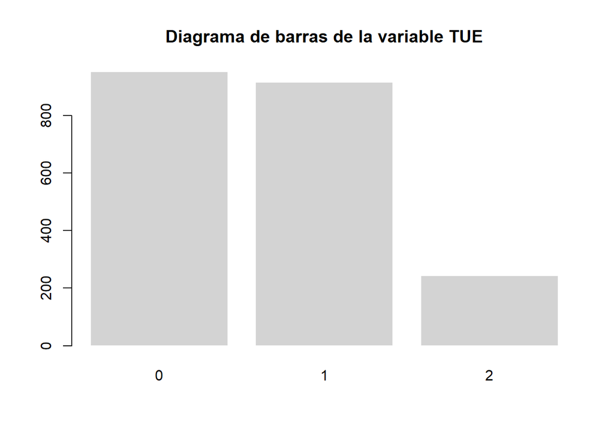

```r
barplot(table(round(obesity_data_raw$TUE)), main="Diagrama de barras de la variable TUE", col="light grey", border = "white")
```

Podría existir una relación positiva entre el uso de dispositivos electrónicos y la obesidad, suponiendo que las personas que pasan tiempo utilizando este tipo de dispositivos dediquen menos tiempo a actividades físicas. Así que este punto de vista supone, por así decirlo, que esta variable es la contrapartida de la variable FAF, que describe el nivel de actividad física (véase más arriba).

#### **Transformaciones**

En el conjunto de datos original, la variable TUE tome valores descimales, algo aue no es conforme con el hecho que es una variable discreta. Por eso, vamos a redondearla.

```r
obesity_data_preprocessed$Tech_Devices_Use = as.integer(round(obesity_data_preprocessed$TUE))
```

#### **1.18. CALC / Alcohol_Consumption**

Se trata de una variable discreta ordinal que indica como de frequene el/la encuestado/-a consume alcohol.

```r
table(factor(obesity_data_raw$CALC, levels = c("no", "Sometimes", "Frequently", "Always")))
```

```
##
##         no  Sometimes Frequently     Always
##        639       1401         70          1
```

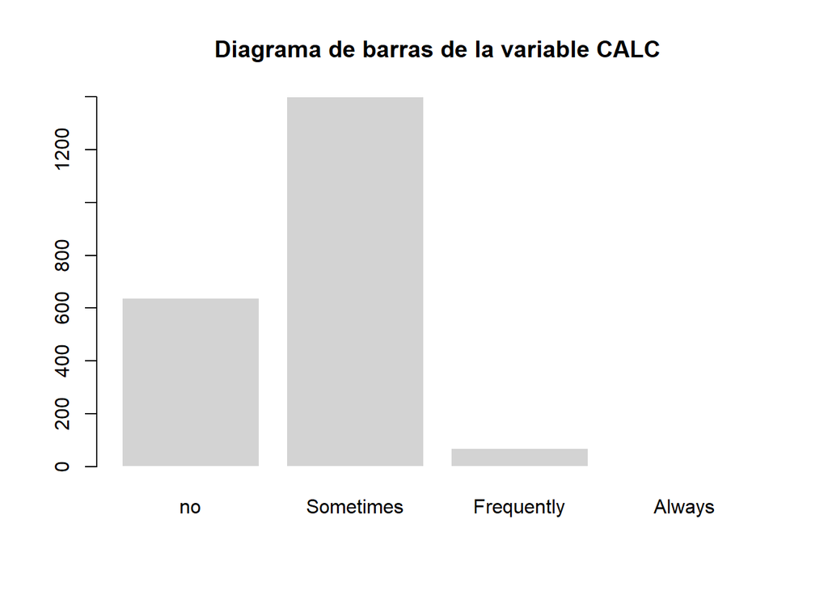

```r
barplot(table(factor(obesity_data_raw$CALC, levels = c("no", "Sometimes", "Frequently", "Always"))), main="Diagrama de barras de la variable CALC", col="light grey", border = "white")
```

Se sabe que el alcohol engorda, por lo que se espera una relación positiva entre la frecuencia del consumo de alcohol y la clase de peso.

Sin embargo, como ha ocurrido con variables anteriores, hay que señalar que las categorías no están claramente delimitadas: ¿qué se entiende por ‘a veces’, por ‘con frecuencia’ y por ‘siempre’?

#### **Transformaciones**

Para empezar, observamos que sólo una encuestada indicó que «siempre» bebe alcohol. Además, no está claro qué se entiende por esta categoría y en qué se diferencia del grupo de bebedores frecuentes de alcohol.

Por estos motivos, eliminaremos la última categoría; la persona que se encuentre en esta categoría será reclasificada una categoría por debajo.

Segudno, aplicamos ‘label encoding’, es decir, sustituiremos los valores que consisten de texto por valores numéricos, de acuerdo con la siguente asignación.

- 0 - Nunca
- 1 - De vez en cuando
- 2 - Frequentemente

#### 1.19. MTRANS / Transport_Mean_Moto / Transport_Mean_Bike / Transport_Mean_Public_Transport / Transport_Mean_Foot

MTRANS es una variabele categorica nominal. Indica el medio de transporte más usado por el/la encuestado/-a.

```r
table(obesity_data_raw$MTRANS)
```

```
##
##            Automobile                  Bike             Motorbike
##                   457                     7                    11
## Public_Transportation               Walking
##                  1580                    56
```

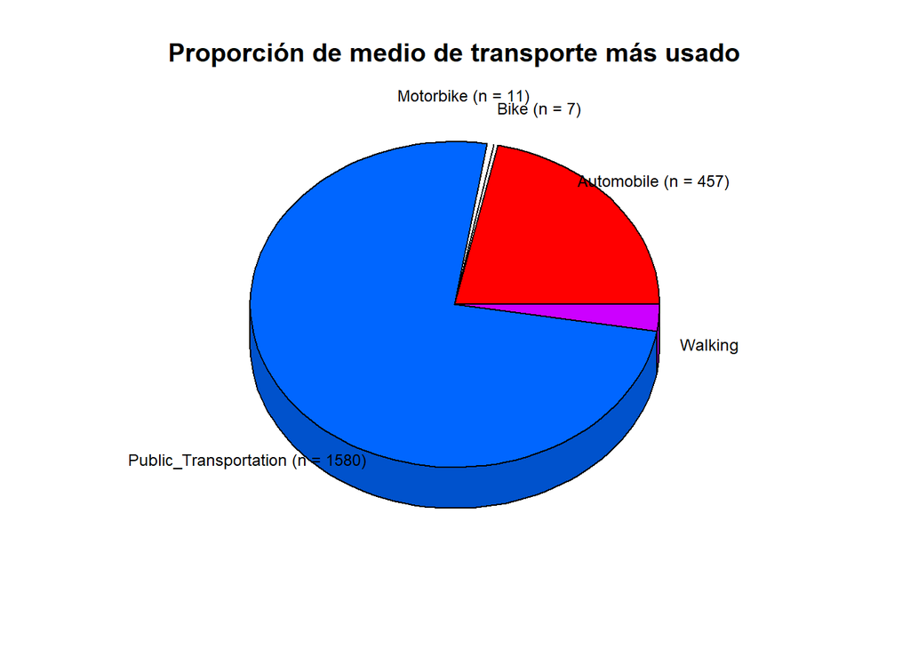

```r
pie3D(table(as.factor(obesity_data_raw$MTRANS)), main = "Proporción de medio de transporte más usado", labels = c("Automobile (n = 457)", "Bike (n = 7)", "Motorbike (n = 11)", "Public_Transportation (n = 1580)", "Walking"), theta = 1.25, labelcex = 0.75)
```

Se espera cierta relación entre medio de transporte más usado y peso - Los que van a pie o en bicicleta queman más calorías que los que van en coche o en moto.

El transporte público se situará en un punto intermedio, ya que implica desplazarse hasta la parada y, en algunos casos, hacer transbordo, dos cosas que también implican actividad física.

#### **Transformaciones**

Aplicamos one-hot encoding - es que decir, vamos a añadir una columna por cada valor que existe pare el variable “MTRANS”; si la fila contiene el valor para el variable MTRANS que coincide con las respectiva columna, el valor de esa columna seŕá 1; en el caso contrario seŕa 0 .

```r
obesity_data_preprocessed$Transport_Mean_Automobile = as.integer(
    ifelse(
      obesity_data_preprocessed$MTRANS == "Automobile", 1, 0
  )
)

obesity_data_preprocessed$Transport_Mean_Bike = as.integer(
  ifelse(
    obesity_data_preprocessed$MTRANS == "Bike", 1, 0
  )
)

obesity_data_preprocessed$Transport_Mean_Motorbike = as.integer(
  ifelse(
    obesity_data_preprocessed$MTRANS == "Motorbike", 1, 0
  )
)

obesity_data_preprocessed$Transport_Mean_Public_Transport = as.integer(
  ifelse(
    obesity_data_preprocessed$MTRANS == "Public_Transportation", 1, 0
  )
)

obesity_data_preprocessed$Transport_Mean_Foot = as.integer(
  ifelse(
    obesity_data_preprocessed$MTRANS == "Walking", 1, 0
  )
)
```

#### **Finalmente…**

Por último, nos deshacemos de las columnas y del conjunto de datos que ya no necesitamos y colocamos las variables en un orden lógico.

```r
#obesity_data_preprocessed = obesity_data_preprocessed[,c("Gender", "Age", "Height", "Weight", "BMI", "Weight_Class_Mendoza_De_La_Hoz", "Weight_Class_WHO", "Overweight_Family", "High_Caloric_Consumption", "Vegetable_Consumption", "Main_Meals", "Between_Meals", "Smoker", "Water_Consumption", "Calory_Monitoring", "Physical_Activity", "Tech_Devices_Use", "Alcohol_Consumption", "Transport_Mean_Automobile", "Transport_Mean_Motorbike", "Transport_Mean_Bike", "Transport_Mean_Public_Transport", "Transport_Mean_Foot")]

rm(obesity_data_raw)
```

## **2.Modelos Predictivos de Clasificación Binaria**

## **2.1 Modelo Predictivo para detectar si un usuario es fumador o no**

#### **2.1.1 Procede con la carga de datos**

```r
datatrain <- read.csv('./data/ObesityDataSet_raw_and_data_sinthetic.csv')
```

#### **2.1.2 Revisión del Dataset para evaluar la variable a utilizar para el modelo predictivo**

```r
str(datatrain)
```

```
## 'data.frame':    2111 obs. of  17 variables:
##  $ Gender                        : chr  "Female" "Female" "Male" "Male" ...
##  $ Age                           : num  21 21 23 27 22 29 23 22 24 22 ...
##  $ Height                        : num  1.62 1.52 1.8 1.8 1.78 1.62 1.5 1.64 1.78 1.72 ...
##  $ Weight                        : num  64 56 77 87 89.8 53 55 53 64 68 ...
##  $ family_history_with_overweight: chr  "yes" "yes" "yes" "no" ...
##  $ FAVC                          : chr  "no" "no" "no" "no" ...
##  $ FCVC                          : num  2 3 2 3 2 2 3 2 3 2 ...
##  $ NCP                           : num  3 3 3 3 1 3 3 3 3 3 ...
##  $ CAEC                          : chr  "Sometimes" "Sometimes" "Sometimes" "Sometimes" ...
##  $ SMOKE                         : chr  "no" "yes" "no" "no" ...
##  $ CH2O                          : num  2 3 2 2 2 2 2 2 2 2 ...
##  $ SCC                           : chr  "no" "yes" "no" "no" ...
##  $ FAF                           : num  0 3 2 2 0 0 1 3 1 1 ...
##  $ TUE                           : num  1 0 1 0 0 0 0 0 1 1 ...
##  $ CALC                          : chr  "no" "Sometimes" "Frequently" "Frequently" ...
##  $ MTRANS                        : chr  "Public_Transportation" "Public_Transportation" "Public_Transportation" "Walking" ...
##  $ NObeyesdad                    : chr  "Normal_Weight" "Normal_Weight" "Normal_Weight" "Overweight_Level_I" ...
```

```r
summary(datatrain)
```

```
##     Gender               Age            Height          Weight
##  Length:2111        Min.   :14.00   Min.   :1.450   Min.   : 39.00
##  Class :character   1st Qu.:19.95   1st Qu.:1.630   1st Qu.: 65.47
##  Mode  :character   Median :22.78   Median :1.700   Median : 83.00
##                     Mean   :24.31   Mean   :1.702   Mean   : 86.59
##                     3rd Qu.:26.00   3rd Qu.:1.768   3rd Qu.:107.43
##                     Max.   :61.00   Max.   :1.980   Max.   :173.00
##  family_history_with_overweight     FAVC                FCVC
##  Length:2111                    Length:2111        Min.   :1.000
##  Class :character               Class :character   1st Qu.:2.000
##  Mode  :character               Mode  :character   Median :2.386
##                                                    Mean   :2.419
##                                                    3rd Qu.:3.000
##                                                    Max.   :3.000
##       NCP            CAEC              SMOKE                CH2O
##  Min.   :1.000   Length:2111        Length:2111        Min.   :1.000
##  1st Qu.:2.659   Class :character   Class :character   1st Qu.:1.585
##  Median :3.000   Mode  :character   Mode  :character   Median :2.000
##  Mean   :2.686                                         Mean   :2.008
##  3rd Qu.:3.000                                         3rd Qu.:2.477
##  Max.   :4.000                                         Max.   :3.000
##      SCC                 FAF              TUE             CALC
##  Length:2111        Min.   :0.0000   Min.   :0.0000   Length:2111
##  Class :character   1st Qu.:0.1245   1st Qu.:0.0000   Class :character
##  Mode  :character   Median :1.0000   Median :0.6253   Mode  :character
##                     Mean   :1.0103   Mean   :0.6579
##                     3rd Qu.:1.6667   3rd Qu.:1.0000
##                     Max.   :3.0000   Max.   :2.0000
##     MTRANS           NObeyesdad
##  Length:2111        Length:2111
##  Class :character   Class :character
##  Mode  :character   Mode  :character
##
##
##
```

Con la revisión del dataset y sus variables se determina que para desarrollar el modelo predictivo si una persona es fumador o no, se debe seleccionar la variable Smoke, el cuál es una variable categórica binaria(“Yes/NO”), y debe convertirse sus valores en binarios númerico para que puedan funcionar en un modelo de clasificación predictivo como Regresión Logistica(Binomial),Árboles de Decisión, KKN, SVm y aplicar métricas como: accurary,F1-SCore, recall, precisión, matriz de confusión entre otras.

#### **2.1.3 Verificar la Factibilidad de la Variable SMOKE**

Se debe analizar la variable “SMOKE”, para determinar si es factible para predicir si una persona es o no fumador

```r
#Se procede a convertir a binario
datatrain$SMOKE <- ifelse(datatrain$SMOKE == "yes", 1, 0)
```

```r
# Se verifica Frecuencia o cantidad de casos (NO Fumadores = 0/Fumadores =1)
table(datatrain$SMOKE)
```

```
##
##    0    1
## 2067   44
```

```r
# Se valida el %Porcentaje  de los datos observados (NO Fumadores = 0/Fumadores =1)
prop.table(table(datatrain$SMOKE))
```

```
##
##         0         1
## 0.9791568 0.0208432
```

Para que funcione bien el modelo de predicción debe aplicarse técnicas adicionales para balancear los datos, pero para efectos de este proyecto vamos realizar la predicciones sin hacer el balanceo validar la teoría que indica esto afectaria los modelos predictivos y sus métricas